# dapR2 Week 11: Paper Analyses

2022-11-28

# Paper 1:

Big thanks to Helena Radke who offered this paper as one with open data that we could look at.

Radke, H.R.M., Kutlaca, M., & Becker, J.C. (2022). Applying the Dynamic Dual Pathway Model of Approach Coping to Collective Action Among Advantaged Group Allies and Disadvantaged Group Members. *Frontiers in Psychology*

The paper is available [here](https://www.frontiersin.org/articles/10.3389/fpsyg.2022.875848/full)

The data set is available for download in the supplementary material at this linlk.

# Key hypothesis

*The aim of the current study was to apply the dynamic dual pathway model of coping with collective disadvantage (Van Zomeren et al., 2012) to advantaged group allies and disadvantaged group members who were participating in a protest. We propose that the problem-focused approach for disadvantaged group members, and the emotion-focused approach for advantaged group members, would be particularly relevant to understanding intentions to engage in future collective action. We therefore hypothesized that group efficacy beliefs would be a stronger predictor of future collective action intentions among disadvantaged group members compared to allies, and group-based anger would be a stronger predictor of future collective action intentions among allies compared to disadvantaged group members. To test this hypothesis, we collected data from allies (heterosexual people) and disadvantaged group members (members of the LGBTIQ+ community) who protested as part of the 2019 Christopher Street Day Parade in Cologne, Germany.*

- Hypothesis 1: group efficacy beliefs would be a stronger predictor of future collective action intentions among disadvantaged group members compared to allies
- Hypothesis 2: group-based anger would be a stronger predictor of future collective action intentions among allies compared to disadvantaged group members

# Read in data

```r
library(tidyverse)
library(interactions)
radke <- read_csv("m:/Academic/Teaching/dapr_new/dapr2/dapr2_lectures/Radke_etal_data.CSV")
```

# Measured variables

- **Group Efficacy Beliefs** :
  - In paper labelled `Group Efficacy`
  - In data set measured with 4 variables labelled `groupeff1`, `groupeff2`, `groupeff3`, `groupeff4`
- **Group-Based Anger**:
  - In paper labelled `Group-based anger`
  - In data set measured with 3 variables labelled `anger1`, `anger2`, `anger3`
- **Future Collective Action Intentions**:
  - In paper labelled `Future CA`
  - In In data set measured with 8 variables labelled `ca1` to `ca8`
- **Previous Experience Engaging in Collective Action for LGBTIQ+ Rights**
  - In paper labelled `CA Experience`
  - In data set labelled `pastaction`
- **Education**:
  - In paper labelled `Education`
  - In data set labelled `edu`
- **Age**:
  - In paper labelled `Age`
  - In data set labelled `age`
- There are a set of variables it is tricky to place:
  - `sexcount`
  - `lgbtcount`
  - `nationcount`

We are going to want to look at the variable types:

```r
str(radke)
```

```
## spec_tbl_df [189 × 22] (S3: spec_tbl_df/tbl_df/tbl/data.frame)
##  $ participantnumber: num [1:189] 1 2 3 4 7 8 9 10 11 12 ...
##  $ anger1           : num [1:189] 7 6 3 6 6 5 4 3 7 6 ...
##  $ anger2           : num [1:189] 5 6 5 5 6 7 4 3 7 6 ...
##  $ anger3           : num [1:189] 5 6 1 4 6 6 4 1 7 4 ...
##  $ groupeff1        : num [1:189] 5 7 7 7 7 7 6 7 7 6 ...
##  $ groupeff2        : num [1:189] 6 7 6 4 7 7 6 7 6 6 ...
##  $ groupeff3        : num [1:189] 5 7 7 4 7 7 6 7 6 5 ...
##  $ groupeff4        : num [1:189] 6 7 6 4 7 7 6 7 6 6 ...
##  $ ca1              : num [1:189] 5 5 1 1 4 4 1 1 6 3 ...
##  $ ca2              : num [1:189] 5 5 1 1 4 1 1 1 5 6 ...
##  $ ca3              : num [1:189] 7 6 5 1 6 5 1 1 7 3 ...
##  $ ca4              : num [1:189] 6 3 1 1 6 4 1 1 7 3 ...
##  $ ca5              : num [1:189] 7 6 5 1 5 5 1 6 7 6 ...
##  $ ca6              : num [1:189] 7 6 1 1 3 2 1 2 7 3 ...
##  $ ca7              : num [1:189] 7 4 1 4 6 3 1 4 5 6 ...
##  $ ca8              : num [1:189] 5 4 1 1 6 5 1 2 3 1 ...
##  $ pastaction       : num [1:189] 4 5 5 1 5 4 1 3 4 6 ...
##  $ age              : num [1:189] 24 23 27 52 36 19 51 25 18 20 ...
##  $ sexcount         : num [1:189] 1 1 1 1 1 1 1 0 1 0 ...
##  $ lgbtcount        : num [1:189] 0 0 0 0 0 0 0 0 0 0 ...
##  $ nationcount      : num [1:189] 1 1 1 1 1 1 1 1 1 1 ...
##  $ edu              : num [1:189] 5 5 4 3 5 1 4 5 4 5 ...
##  - attr(*, "spec")=
##   .. cols(
##   ..   participantnumber = col_double(),
##   ..   anger1 = col_double(),
##   ..   anger2 = col_double(),
##   ..   anger3 = col_double(),
##   ..   groupeff1 = col_double(),
##   ..   groupeff2 = col_double(),
##   ..   groupeff3 = col_double(),
##   ..   groupeff4 = col_double(),
##   ..   ca1 = col_double(),
##   ..   ca2 = col_double(),
##   ..   ca3 = col_double(),
##   ..   ca4 = col_double(),
##   ..   ca5 = col_double(),
##   ..   ca6 = col_double(),
##   ..   ca7 = col_double(),
##   ..   ca8 = col_double(),
##   ..   pastaction = col_double(),
##   ..   age = col_double(),
##   ..   sexcount = col_double(),
##   ..   lgbtcount = col_double(),
##   ..   nationcount = col_double(),
##   ..   edu = col_double()
##   .. )
##  - attr(*, "problems")=<externalptr>
```

# Participant checks

```r
table(radke$sexcount)
```

```
##
##   0   1
##  75 108
```

```r
table(radke$lgbtcount)
```

```
##
##   0   1
##  64 125
```

```r
table(radke$edu)
```

```
##
##  1  2  3  4  5
##  8  9 31 77 62
```

```r
radke %>%
  summarise(
    mean = mean(age, na.rm = T),
    sd = sd(age, na.rm=T)
  )
```

```
## # A tibble: 1 × 2
##    mean    sd
##   <dbl> <dbl>
## 1  27.5  10.4
```

## Converting variables:

- gender identity = categorical variable
- group membership = binary
- education = ordered factor

```r
radke <- radke %>%
  mutate(
    sexcount = factor(sexcount, labels = c("m", "f")),
    lgbtcount = factor(lgbtcount, labels = c("hetero", "lgbt")),
    education = factor(edu, ordered = T)
  )
```

# Descriptive statistic checks

## Scoring variables

```r
radke <- radke %>%
  mutate(
    anger = round(rowMeans(select(., c("anger1", "anger2", "anger3")), na.rm=T),3),
    ca = round(rowMeans(select(., c("ca1", "ca2", "ca3", "ca4", "ca5", "ca6", "ca7", "ca8")), na.rm=T),3),
    geff = round(rowMeans(select(., c("groupeff1", "groupeff2", "groupeff3", "groupeff4")), na.rm=T),3)
  )
```

## Table 1 values

- Descriptive by group

```r
radke %>%
  group_by(lgbtcount) %>%
  select(age, pastaction, geff, anger, ca) %>%
  summarise_all(., mean, na.rm=T)
```

```
## # A tibble: 2 × 6
##   lgbtcount   age pastaction  geff anger    ca
##   <fct>     <dbl>      <dbl> <dbl> <dbl> <dbl>
## 1 hetero     29.4       3.48  5.99  4.51  4.12
## 2 lgbt       26.6       4.80  6.16  4.33  4.77
```

```r
radke %>%
  group_by(lgbtcount) %>%
  select(age, pastaction, geff, anger, ca) %>%
  summarise_all(., sd, na.rm=T)
```

```
## # A tibble: 2 × 6
##   lgbtcount   age pastaction  geff anger    ca
##   <fct>     <dbl>      <dbl> <dbl> <dbl> <dbl>
## 1 hetero    12.1        1.92  1.20  1.74  1.45
## 2 lgbt       9.25       1.89  1.03  1.72  1.31
```

- Correlations by group

```r
radke_lgbt <- radke %>% filter(lgbtcount == "lgbt") %>%
  select(age, pastaction, geff, anger, ca)
radke_het <- radke %>% filter(lgbtcount == "hetero")%>%
  select(age, pastaction, geff, anger, ca)

round(cor(radke_lgbt, use = "pairwise.complete.obs"),2)
```

```
##              age pastaction  geff anger    ca
## age         1.00      -0.06 -0.01 -0.08 -0.04
## pastaction -0.06       1.00  0.34  0.04  0.49
## geff       -0.01       0.34  1.00  0.09  0.37
## anger      -0.08       0.04  0.09  1.00  0.20
## ca         -0.04       0.49  0.37  0.20  1.00
```

```r
round(cor(radke_het, use = "pairwise.complete.obs"),2)
```

```
##              age pastaction  geff anger    ca
## age         1.00      -0.29 -0.28 -0.07 -0.22
## pastaction -0.29       1.00  0.26  0.07  0.39
## geff       -0.28       0.26  1.00  0.10  0.05
## anger      -0.07       0.07  0.10  1.00  0.37
## ca         -0.22       0.39  0.05  0.37  1.00
```

# Models

*We used Mplus version 8.6 to run a moderation model with two predictors (group-based anger and group efficacy), group membership as the dichotomous moderator (advantaged group allies = 0; disadvantaged group members = 1), and future collective action intentions as the outcome (Stride et al., 2015). We opted for maximum likelihood estimation with robust standard errors (MLR). Regression analyses were conducted, the variables were mean-centered, and the analysis was conducted on the observed variables so no model fit indices are reported (see Table 2).*

Importantly it also states under table 2 that age, sex, nationality, level of education and past collective action experience are covariates.

- Mean centre

```r
radke <- radke %>%
  mutate(
    anger_m  = scale(anger, center=T, scale = F),
    geff_m  = scale(geff, center=T, scale = F)
  )
```

- Unadjusted model

```r
m1 <- lm(ca ~ anger_m + geff_m + lgbtcount + anger_m*lgbtcount + geff_m*lgbtcount, data = radke)
summary(m1)
```

```
##
## Call:
## lm(formula = ca ~ anger_m + geff_m + lgbtcount + anger_m * lgbtcount +
##     geff_m * lgbtcount, data = radke)
##
## Residuals:
##     Min      1Q  Median      3Q     Max
## -3.3516 -0.8913  0.1010  0.7639  3.2699
##
## Coefficients:
##                       Estimate Std. Error t value Pr(>|t|)
## (Intercept)            4.08886    0.15934  25.661  < 2e-16 ***
## anger_m                0.30396    0.09195   3.306 0.001139 **
## geff_m                 0.01451    0.13352   0.109 0.913580
## lgbtcountlgbt          0.66572    0.19559   3.404 0.000817 ***
## anger_m:lgbtcountlgbt -0.17672    0.11331  -1.560 0.120566
## geff_m:lgbtcountlgbt   0.43223    0.17312   2.497 0.013418 *
## ---
## Signif. codes:  0 '***' 0.001 '**' 0.01 '*' 0.05 '.' 0.1 ' ' 1
##
## Residual standard error: 1.265 on 183 degrees of freedom
## Multiple R-squared:  0.1934, Adjusted R-squared:  0.1714
## F-statistic: 8.777 on 5 and 183 DF,  p-value: 1.755e-07
```

- simple slopes

```r
sim_slopes(m1,
           pred = geff_m,
           modx = lgbtcount)
```

```
## SIMPLE SLOPES ANALYSIS
##
## Slope of geff_m when lgbtcount = lgbt:
##
##   Est.   S.E.   t val.      p
## ------ ------ -------- ------
##   0.45   0.11     4.05   0.00
##
## Slope of geff_m when lgbtcount = hetero:
##
##   Est.   S.E.   t val.      p
## ------ ------ -------- ------
##   0.01   0.13     0.11   0.91
```

- Covariate model

```r
m2 <- lm(ca ~ anger_m + geff_m + lgbtcount + anger_m*lgbtcount + geff_m*lgbtcount
         + sexcount + age + edu + nationcount + pastaction, data = radke)
summary(m2)
```

```
##
## Call:
## lm(formula = ca ~ anger_m + geff_m + lgbtcount + anger_m * lgbtcount +
##     geff_m * lgbtcount + sexcount + age + edu + nationcount +
##     pastaction, data = radke)
##
## Residuals:
##      Min       1Q   Median       3Q      Max
## -2.53474 -0.78895 -0.00728  0.77473  2.80736
##
## Coefficients:
##                        Estimate Std. Error t value Pr(>|t|)
## (Intercept)            3.512000   0.559838   6.273 3.06e-09 ***
## anger_m                0.273975   0.082796   3.309  0.00115 **
## geff_m                -0.134344   0.124341  -1.080  0.28154
## lgbtcountlgbt          0.310782   0.192424   1.615  0.10823
## sexcountf              0.179804   0.177566   1.013  0.31275
## age                   -0.007731   0.008698  -0.889  0.37545
## edu                   -0.021726   0.089763  -0.242  0.80906
## nationcount           -0.265778   0.291769  -0.911  0.36368
## pastaction             0.289400   0.047593   6.081 8.21e-09 ***
## anger_m:lgbtcountlgbt -0.095468   0.103559  -0.922  0.35796
## geff_m:lgbtcountlgbt   0.372231   0.159483   2.334  0.02082 *
## ---
## Signif. codes:  0 '***' 0.001 '**' 0.01 '*' 0.05 '.' 0.1 ' ' 1
##
## Residual standard error: 1.119 on 163 degrees of freedom
##   (15 observations deleted due to missingness)
## Multiple R-squared:  0.3804, Adjusted R-squared:  0.3424
## F-statistic: 10.01 on 10 and 163 DF,  p-value: 5.384e-13
```

```r
sim_slopes(m2,
           pred = geff_m,
           modx = lgbtcount)
```

```
## SIMPLE SLOPES ANALYSIS
##
## Slope of geff_m when lgbtcount = lgbt:
##
##   Est.   S.E.   t val.      p
## ------ ------ -------- ------
##   0.24   0.11     2.26   0.03
##
## Slope of geff_m when lgbtcount = hetero:
##
##    Est.   S.E.   t val.      p
## ------- ------ -------- ------
##   -0.13   0.12    -1.08   0.28
```

# Make a plot

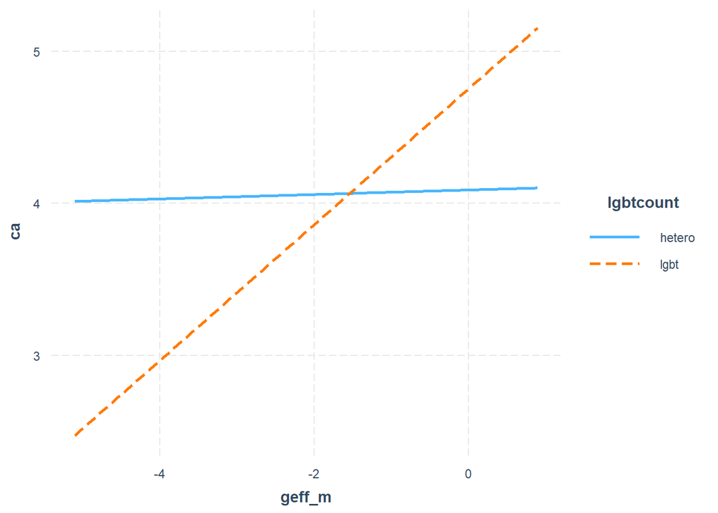

```r
interact_plot(m1,
              pred = geff_m,
              modx = lgbtcount,
              ylim = c(1, 7))
```